# ML #3 Predictive Policing

Michael Dunst and Sofia Fosullo

10/21/2022

## Introduction

> The purpose of this project is to create an accurate model to predict a certain area’s probability of a crime occuring within it.

## Read in Vandalism Data from Chicago

```r
policeDistricts <-
  st_read("https://data.cityofchicago.org/api/geospatial/fthy-xz3r?method=export&format=GeoJSON") %>%
  st_transform('ESRI:102271') %>%
  dplyr::select(District = dist_num)
policeBeats <-
  st_read("https://data.cityofchicago.org/api/geospatial/aerh-rz74?method=export&format=GeoJSON") %>%
  st_transform('ESRI:102271') %>%
  dplyr::select(District = beat_num)
bothPoliceUnits <- rbind(mutate(policeDistricts, Legend = "Police Districts"),
                         mutate(policeBeats, Legend = "Police Beats"))

vandalism <-
  read.socrata("https://data.cityofchicago.org/Public-Safety/Crimes-2017/d62x-nvdr") %>%
    filter(Primary.Type == "CRIMINAL DAMAGE" & Description == "TO PROPERTY") %>%
    mutate(x = gsub("[()]", "", Location)) %>%
    separate(x,into= c("Y","X"), sep=",") %>%
    mutate(X = as.numeric(X),Y = as.numeric(Y)) %>%
    na.omit() %>%
    st_as_sf(coords = c("X", "Y"), crs = 4326, agr = "constant")%>%
    st_transform('ESRI:102271') %>%
    distinct()

chicagoBoundary <-
  st_read(file.path(root.dir,"/Chapter5/chicagoBoundary.geojson")) %>%
  st_transform('ESRI:102271')
```

## Visualizing Point Data

Plotting point data and density

> Our outcome of interest in this study is a prediction of vandalism sites accurate to actual reported vandalism sites. We think that data collected on vandalism of property could contain selection bias for several reasons. One factor that could play a role in the reporting of property damage would be property ownership, with homeowners assumed to be more likely to notice and report vandalism than absentee who landlords, who may not notice or care as much to invest and repair the damage. It should be noticed as well that we sourced our data from the Chicago Police, so the vandalism reports recorded were from police calls. Different socioeconomic and racial groups may have different views on reporting property damage to police, with people of color, especially black people being disproportionately affected by police brutality in America, it is possible that vandalism is underreported by people of color and renters.

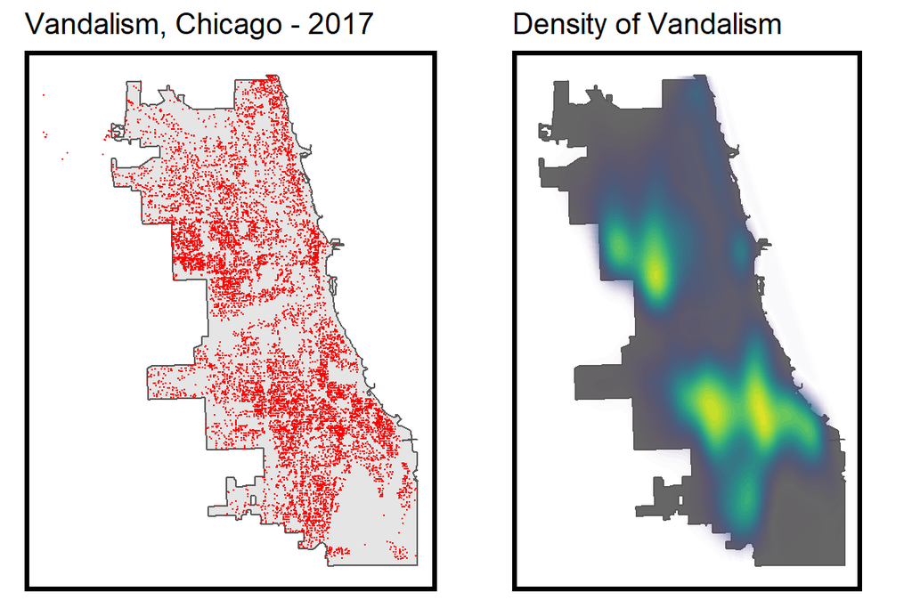

```r
# uses grid.arrange to organize independent plots
grid.arrange(ncol=2,
ggplot() +
  geom_sf(data = chicagoBoundary) +
  geom_sf(data = vandalism, colour="red", size=0.1, show.legend = "point") +
  labs(title= "Vandalism, Chicago - 2017") +
  mapTheme(title_size = 14),

ggplot() +
  geom_sf(data = chicagoBoundary, fill = "grey40") +
  stat_density2d(data = data.frame(st_coordinates(vandalism)),
                 aes(X, Y, fill = ..level.., alpha = ..level..),
                 size = 0.01, bins = 40, geom = 'polygon') +
  scale_fill_viridis() +
  scale_alpha(range = c(0.00, 0.35), guide = FALSE) +
  labs(title = "Density of Vandalism") +
  mapTheme(title_size = 14) + theme(legend.position = "none"))
```

> First, we create a fishnet grid to objectify the process by ensuring spatial data is being summarized over a uniform spatial division. In this case, this is a 500-meter square.

```r
## using {sf} to create the grid
## Note the `.[chicagoBoundary] %>% ` line. This is needed to clip the grid to our data
fishnet <-
  st_make_grid(chicagoBoundary,
               cellsize = 500,
               square = TRUE) %>%
  .[chicagoBoundary] %>%            # fast way to select intersecting polygons
  st_sf() %>%
  mutate(uniqueID = 1:n())
```

### Aggregate points to the fishnet

> In the figure below we map our data on 2017 property vandalism reports aggregated to a fishnet. A fishnet is a uniform grid of cells, in our case 500 meters each. By aggregating our data to uniformly sized shapes, we are avoiding a spatial error in which the aggregation is biased to certain boundaries. A common implementation of this spatial error is gerrymandering. Thus, our fishnet is a step to reduce bias in the prediction of vandalism.

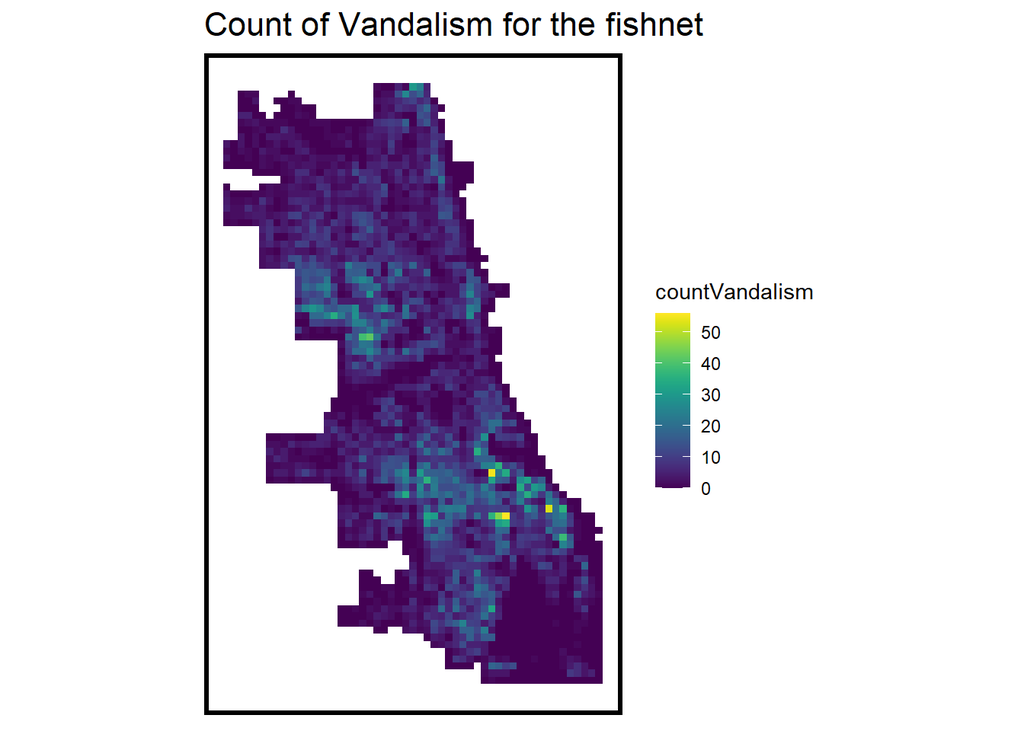

```r
## add a value of 1 to each crime, sum them with aggregate
crime_net <-
  dplyr::select(vandalism) %>%
  mutate(countVandalism = 1) %>%
  aggregate(., fishnet, sum) %>%
  mutate(countVandalism = replace_na(countVandalism, 0),
         uniqueID = 1:n(),
         cvID = sample(round(nrow(fishnet) / 24),
                       size=nrow(fishnet), replace = TRUE))

ggplot() +
  geom_sf(data = crime_net, aes(fill = countVandalism), color = NA) +
  scale_fill_viridis() +
  labs(title = "Count of Vandalism for the fishnet") +
  mapTheme()
```

```r
# For demo. requires updated mapview package
# xx <- mapview::mapview(crime_net, zcol = "countBurglaries")
# yy <- mapview::mapview(mutate(burglaries, ID = seq(1:n())))
# xx + yy
```

## Modeling Spatial Features

> We choose two spatial features in addition to those presented in our lab. One such feature was vacant buildings. We chose this feature because we assumed that vacant buildings are viewed as lacking ownership or protection and are more vulnerable to damage as a result. It would make sense under this logic that vacant buildings would be more likely to be vandalized than owned and maintained buildings. We used point data from the Chicago Police Portal on vacant building locations.

> These features may be problematic for two reasons. One is that median household income is not point data, and is aggregated to census block groups which are not uniform in size or population, which may introduce spatial bias. Another reason is that vacancies and median household income were chosen for opposite reasoning. We assume vandalism to occur most on property with no value (vacancies are usually listed as $0 property value) but to be reported most on properties with higher value. This presents a contradiction.

```r
#Pulling locations of vacant buildings
vacantBldgs <-
  read.socrata("https://data.cityofchicago.org/Buildings/Vacant-and-Abandoned-Buildings-Violations/kc9i-wq85") %>%
    mutate(issued_date = substr(issued_date,1,4)) %>% filter(issued_date == "2017") %>%
    dplyr::select(Y = latitude, X = longitude) %>%
    na.omit() %>%
    st_as_sf(coords = c("X", "Y"), crs = 4326, agr = "constant") %>%
    st_transform(st_crs(fishnet)) %>%
    mutate(Legend = "Vacant_Bldgs")
```

```r
#Getting median HH income by Census tract
CHI_demo.sf <-
  get_acs(geography = "block group",
          variables = c("B19013_001E"),
          year=2020, state=17, county=031,
          geometry=TRUE, output="wide") %>%
  st_transform("ESRI:102271") %>%
  dplyr::select( -NAME, -B19013_001M)
CHI_demo.sf <-
  CHI_demo.sf %>%
  rename(HH_inc = B19013_001E)
```

#### How we aggregate a feature to our fishnet

> We added data on abandoned car locations and vacant homes. Using our knowledge of urban planning, we assumed that crimes may cluster spatially, suggesting that car abandonment and vandalism occur in similar areas, and that vacant homes are more likely to be targets of property damage because repurcussions are less likely to be enforced over abandoned property.

```r
#Join count data
vars_net <- abandonCars %>%
  st_join(fishnet, join=st_within) %>%
  st_drop_geometry() %>%
  group_by(uniqueID, Legend) %>%
  summarize(count = n()) %>%
  left_join(fishnet, ., by = "uniqueID") %>%
  spread(Legend, count, fill=0) %>%
  dplyr::select(-`<NA>`) %>%
  ungroup()
vacant_agg <- vacantBldgs %>%
  st_join(fishnet, join=st_within) %>%
  st_drop_geometry() %>%
  group_by(uniqueID, Legend) %>%
  summarize(count = n()) %>%
  left_join(fishnet, ., by = "uniqueID") %>%
  spread(Legend, count, fill=0) %>%
  dplyr::select(-`<NA>`) %>%
  ungroup()
vars_net <- merge(as.data.frame(vars_net), as.data.frame(vacant_agg))
```

```r
#Join income data
vars_net <- st_as_sf(vars_net, sf_column_name = "geometry")

vars_net <- st_join(st_centroid(vars_net), CHI_demo.sf) %>%
  dplyr::select(-`GEOID`)
```

## Mapping Median Household Income data

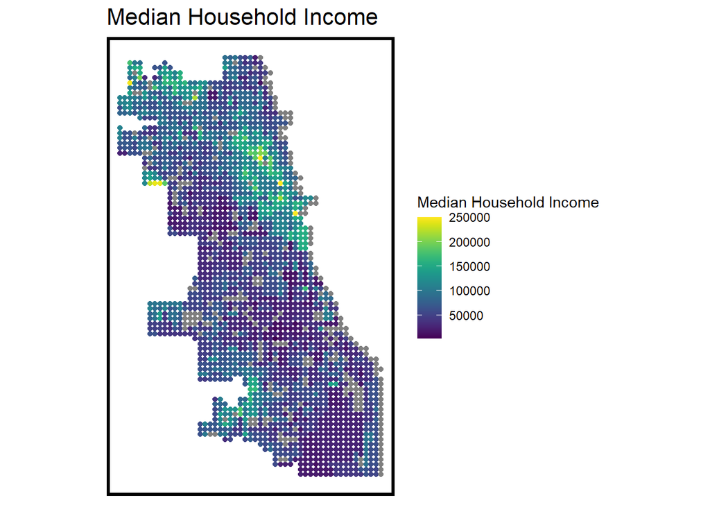

```r
ggplot() +
      geom_sf(data = vars_net, aes(color=HH_inc)) +
      scale_color_viridis(name="Median Household Income") +
      labs(title="Median Household Income") +
  mapTheme()
```

## Nearest Neighbor Feature

> The nearest neighbor algorithm calculates the average proximity between a certain number of points and is a good measure of density of events, in our case crime events.

```r
# convenience to reduce length of function names.
st_c    <- st_coordinates
st_coid <- st_centroid

## create NN from abandoned cars and vacant buildings
vars_net <- vars_net %>%
    mutate(Abandoned_Cars.nn = nn_function(st_c(st_coid(vars_net)), st_c(abandonCars), k = 3)) %>%
  mutate(vacantBldgsNn = nn_function(st_c(st_coid(vars_net)), st_c(vacantBldgs), k = 3))
```

```r
## Visualize the NN feature - abandoned cars
vars_net.long.nn <-
  dplyr::select(vars_net, ends_with(".nn")) %>%
    gather(Variable, value, -geometry)

## Visualize the NN feature - vacant buildings
vars_net.longNn <-
  dplyr::select(vars_net, ends_with("Nn")) %>%
    gather(Variable, value, -geometry)
```

## Join NN feature to our fishnet

> By joining our nearest neighbor calculations to our fishnet grid, we can continue to calculate and display spatial data without summarizing data unevenly accross space.

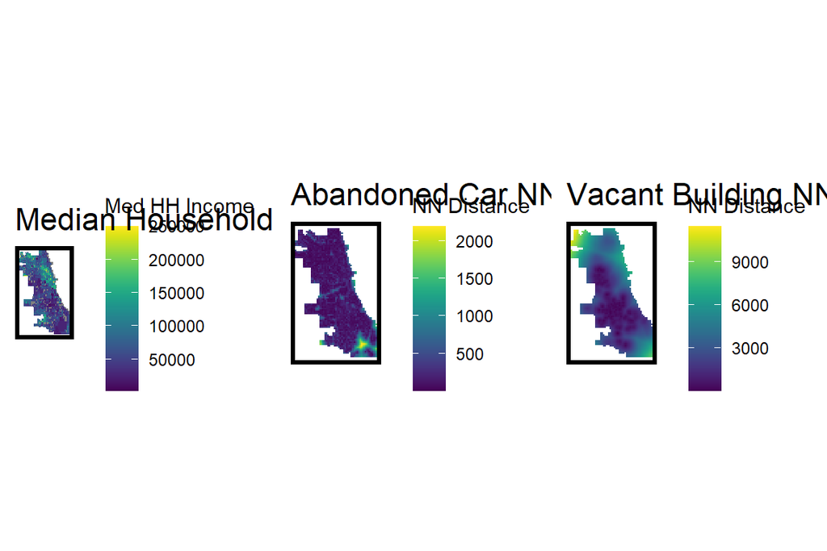

```r
## important to drop the geometry from joining features
final_net <-
  left_join(crime_net, st_drop_geometry(vars_net), by="uniqueID")

grid.arrange(ncol=3,
ggplot() +
      geom_sf(data = final_net, aes(fill=HH_inc), color=NA) +
      scale_fill_viridis(name="Med HH Income") +
      labs(title="Median Household Income") +
      mapTheme(),
ggplot() +
      geom_sf(data = final_net, aes(fill=Abandoned_Cars.nn), color=NA) +
      scale_fill_viridis(name="NN Distance") +
      labs(title="Abandoned Car NN Distance") +
      mapTheme(),
ggplot() +
      geom_sf(data = final_net, aes(fill=vacantBldgsNn), color=NA) +
      scale_fill_viridis(name="NN Distance") +
      labs(title="Vacant Building NN Distance") +
  mapTheme()
)
```

### Join in areal data

```r
final_net <-
  st_centroid(final_net) %>%
    st_join(dplyr::select(neighborhoods, name), by = "uniqueID") %>%
    st_join(dplyr::select(policeDistricts, District), by = "uniqueID") %>%
      st_drop_geometry() %>%
      left_join(dplyr::select(final_net, geometry, uniqueID)) %>%
      st_sf() %>%
  na.omit()
```

```r
# for live demo
# mapview::mapview(final_net, zcol = "District")
```

## Local Moran’s I for fishnet grid cells

> Moran’s I is a good measure for spatial grouping of similar events.

```r
## generates warnings from PROJ issues
## {spdep} to make polygon to neighborhoods...
final_net.nb <- poly2nb(as_Spatial(final_net), queen=TRUE)
## ... and neighborhoods to list of weights
final_net.weights <- nb2listw(final_net.nb, style="W", zero.policy=TRUE)

# print(final_net.weights, zero.policy=TRUE)
```

```r
## see ?localmoran
local_morans_ac <- localmoran(final_net$Abandoned_Cars, final_net.weights, zero.policy=TRUE) %>%
  as.data.frame()

local_morans_vb <- localmoran(final_net$Vacant_Bldgs, final_net.weights, zero.policy=TRUE) %>%
  as.data.frame()

# join local Moran's I results to fishnet
final_net.localMorans_ac <-
  cbind(local_morans_ac, as.data.frame(final_net)) %>%
  st_sf() %>%
  dplyr::select(Abandoned_Cars_Count = Abandoned_Cars,
                Local_Morans_I = Ii,
                P_Value = `Pr(z != E(Ii))`) %>%
  mutate(Significant_Hotspots = ifelse(P_Value <= 0.001, 1, 0)) %>%
  gather(Variable, Value, -geometry)



final_net.localMorans_vb <-
   cbind(local_morans_vb, as.data.frame(final_net)) %>%
  st_sf() %>%
  dplyr::select(Vacant_Bldgs_Count = Vacant_Bldgs,
                Local_Morans_I = Ii,
                P_Value = `Pr(z != E(Ii))`) %>%
  mutate(Significant_Hotspots = ifelse(P_Value <= 0.001, 1, 0)) %>%
  gather(Variable, Value, -geometry)
```

### Plotting local Moran’s I results

> By creating binary “hotspot” regions, we can more clearly display the clustering areas of groups of crime events. One helpful finding is that the central west region of Chicago contains hot spots for both abandoned cars and vacant buildings.

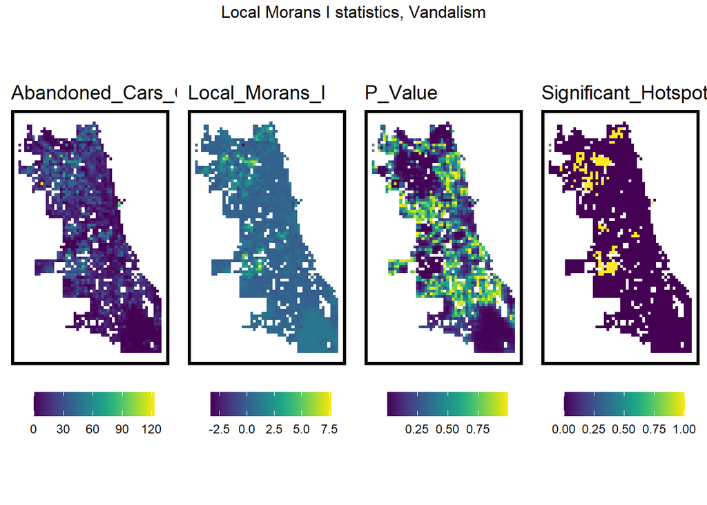

```r
## This is just for plotting
vars <- unique(final_net.localMorans_ac$Variable)
varList <- list()

for(i in vars){
  varList[[i]] <-
    ggplot() +
      geom_sf(data = filter(final_net.localMorans_ac, Variable == i),
              aes(fill = Value), colour=NA) +
      scale_fill_viridis(name="") +
      labs(title=i) +
      mapTheme(title_size = 14) + theme(legend.position="bottom")}

do.call(grid.arrange,c(varList, ncol = 4, top = "Local Morans I statistics, Vandalism"))
```

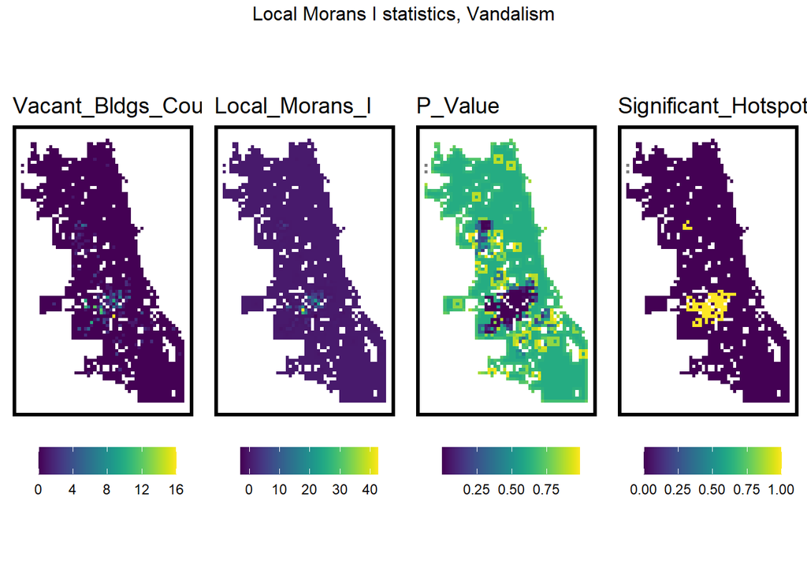

```r
## This is just for plotting
vars <- unique(final_net.localMorans_vb$Variable)
varList <- list()

for(i in vars){
  varList[[i]] <-
    ggplot() +
      geom_sf(data = filter(final_net.localMorans_vb, Variable == i),
              aes(fill = Value), colour=NA) +
      scale_fill_viridis(name="") +
      labs(title=i) +
      mapTheme(title_size = 14) + theme(legend.position="bottom")}

do.call(grid.arrange,c(varList, ncol = 4, top = "Local Morans I statistics, Vandalism"))
```

> It appears that vacant homes are somewhat positively correlated with vandalism and that median household income is somewhat inversely correlated.

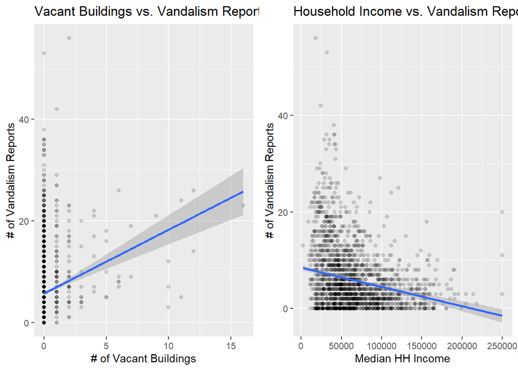

```r
#library(ggpmisc)
grid.arrange(ncol=2,
ggplot(final_net, aes(x=Vacant_Bldgs, y=countVandalism)) +
  geom_point(alpha=0.15) +
  labs(title="Vacant Buildings vs. Vandalism Reports per Grid Square") +
  ylab("# of Vandalism Reports") +
  xlab("# of Vacant Buildings") +
  geom_smooth(method='lm', formula= y~x),
ggplot(final_net, aes(x=HH_inc, y=countVandalism)) +
  geom_point(alpha=0.15) +
  labs(title="Household Income vs. Vandalism Reports per Grid Square") +
  ylab("# of Vandalism Reports") +
  xlab("Median HH Income") +
  geom_smooth(method='lm', formula= y~x))
```

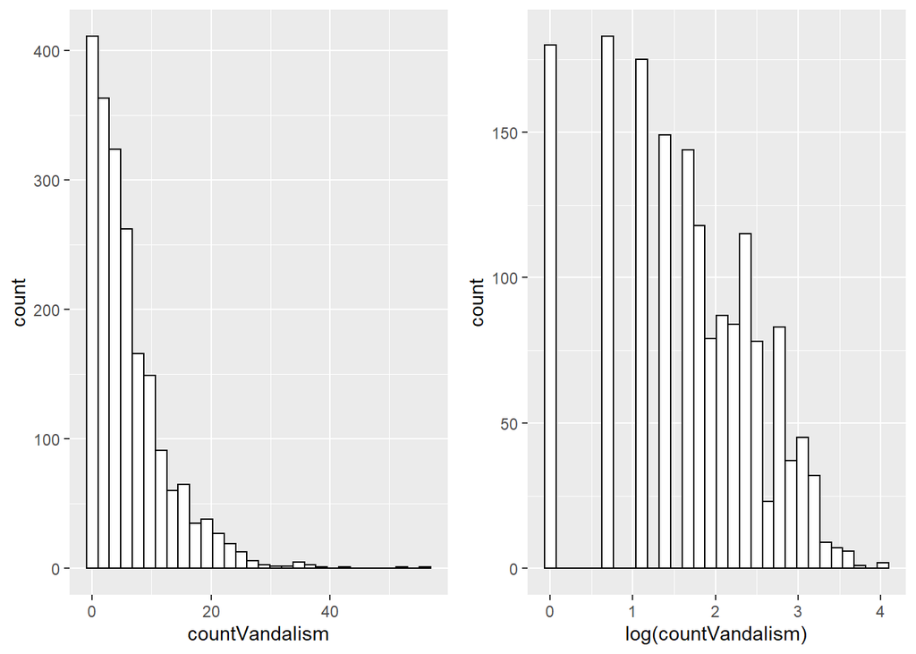

```r
grid.arrange(ncol=2,
ggplot(final_net, aes(countVandalism)) +
  geom_histogram(color="black", fill="white"),
ggplot(final_net, aes(log(countVandalism))) +
  geom_histogram(color="black", fill="white"))
```

## Distance to Hot spot

```r
# generates warning from NN
final_net <- final_net %>%
  mutate(abandoned.isSig =
           ifelse(local_morans_ac[,5] <= 0.001, 1, 0)) %>%
  mutate(abandoned.isSig.dist =
           nn_function(st_c(st_coid(final_net)),
                       st_c(st_coid(filter(final_net,
                                           abandoned.isSig == 1))),
                       k = 1))
```

### Plot NN distance to hot spot

> As shown in our hotspot graphs, we see a density around hot spots in the Central West and North West Chicago areas.

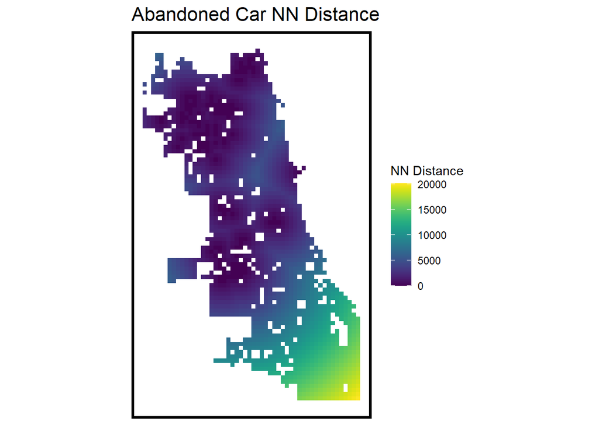

```r
ggplot() +
      geom_sf(data = final_net, aes(fill=abandoned.isSig.dist), colour=NA) +
      scale_fill_viridis(name="NN Distance") +
      labs(title="Abandoned Car NN Distance") +
      mapTheme()
```

## Modeling and CV

> When using Leave One Group Out (LOOCV) on spatial features, we are able to plot an error or prediction term across space for each fishnet cell. We are also testing whether the accuracy of our model is generalizable or dependent on conditions of a specific test set.

[output not shown]

```r
# calculate errors by NEIGHBORHOOD
error_by_reg_and_fold <-
  reg.ss.spatialCV %>%
    group_by(cvID) %>%
    summarize(Mean_Error = mean(Prediction - countVandalism, na.rm = T),
              MAE = mean(abs(Mean_Error), na.rm = T),
              SD_MAE = mean(abs(Mean_Error), na.rm = T)) %>%
  ungroup()

error_by_reg_and_fold %>%
  arrange(desc(MAE))
```

```
## Simple feature collection with 96 features and 4 fields
## Geometry type: GEOMETRY
## Dimension:     XY
## Bounding box:  xmin: 341164.6 ymin: 552874.5 xmax: 367164.6 ymax: 594874.5
## Projected CRS: NAD_1983_HARN_StatePlane_Illinois_East_FIPS_1201
## # A tibble: 96 × 5
##    cvID            Mean_Error   MAE SD_MAE                              geometry
##    <chr>                <dbl> <dbl>  <dbl>                        <GEOMETRY [m]>
##  1 Millenium Park      -18.7  18.7   18.7  POLYGON ((358664.6 578874.5, 359164.…
##  2 Rush & Division     -13.3  13.3   13.3  POLYGON ((358664.6 580874.5, 358164.…
##  3 Loop                -10.4  10.4   10.4  POLYGON ((357664.6 579374.5, 357664.…
##  4 Woodlawn             -8.81  8.81   8.81 POLYGON ((360164.6 566874.5, 359664.…
##  5 Boystown             -8.18  8.18   8.18 POLYGON ((356664.6 585874.5, 357164.…
##  6 Rogers Park          -6.29  6.29   6.29 POLYGON ((354164.6 592874.5, 354164.…
##  7 Washington Park      -6.26  6.26   6.26 POLYGON ((358664.6 569374.5, 358664.…
##  8 South Shore          -6.06  6.06   6.06 MULTIPOLYGON (((361664.6 565874.5, 3…
##  9 Streeterville        -5.93  5.93   5.93 MULTIPOLYGON (((359664.6 579874.5, 3…
## 10 Clearing              5.04  5.04   5.04 MULTIPOLYGON (((344164.6 568374.5, 3…
## # … with 86 more rows
```

```r
error_by_reg_and_fold %>%
  arrange(MAE)
```

```
## Simple feature collection with 96 features and 4 fields
## Geometry type: GEOMETRY
## Dimension:     XY
## Bounding box:  xmin: 341164.6 ymin: 552874.5 xmax: 367164.6 ymax: 594874.5
## Projected CRS: NAD_1983_HARN_StatePlane_Illinois_East_FIPS_1201
## # A tibble: 96 × 5
##    cvID          Mean_Error   MAE SD_MAE                                geometry
##    <chr>              <dbl> <dbl>  <dbl>                          <GEOMETRY [m]>
##  1 North Center       0.108 0.108  0.108 POLYGON ((353164.6 585374.5, 353164.6 …
##  2 Edison Park       -0.114 0.114  0.114 POLYGON ((342664.6 592874.5, 343164.6 …
##  3 West Ridge         0.159 0.159  0.159 POLYGON ((351664.6 592374.5, 351664.6 …
##  4 Andersonville      0.193 0.193  0.193 POLYGON ((354664.6 589874.5, 354664.6 …
##  5 Galewood          -0.208 0.208  0.208 POLYGON ((343664.6 582374.5, 343664.6 …
##  6 Norwood Park       0.253 0.253  0.253 MULTIPOLYGON (((342664.6 589374.5, 342…
##  7 Museum Campus     -0.336 0.336  0.336 MULTIPOLYGON (((359664.6 575374.5, 359…
##  8 Douglas            0.378 0.378  0.378 POLYGON ((358664.6 574374.5, 358664.6 …
##  9 Edgewater         -0.395 0.395  0.395 POLYGON ((356664.6 590874.5, 356664.6 …
## 10 Riverdale         -0.449 0.449  0.449 POLYGON ((360664.6 552874.5, 360164.6 …
## # … with 86 more rows
```

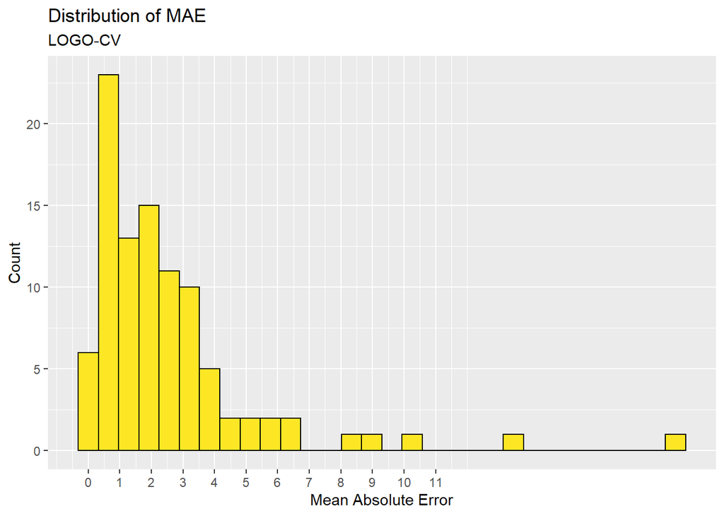

```r
## plot histogram of OOF (out of fold) errors
error_by_reg_and_fold %>%
  ggplot(aes(MAE)) +
    geom_histogram(bins = 30, colour="black", fill = "#FDE725FF") +
  scale_x_continuous(breaks = seq(0, 11, by = 1)) +
    labs(title="Distribution of MAE", subtitle = "LOGO-CV",
         x="Mean Absolute Error", y="Count")
```

## K-Fold Cross Validation

```r
fitControl <- trainControl(method = "cv", number = 100)
set.seed(825)

reg.cv <-
  train(countVandalism ~ ., data = st_drop_geometry(final_net) %>%
                                dplyr::select(countVandalism, all_of(reg.ss.vars)),
     method = "lm", trControl = fitControl, na.action = na.pass)

#reg.cv
#reg.cv$resample[1:5,]

library(data.table)
MAE.cv = data.table(MAE.cv= reg.cv$resample[,3])
```

## Mapping Error

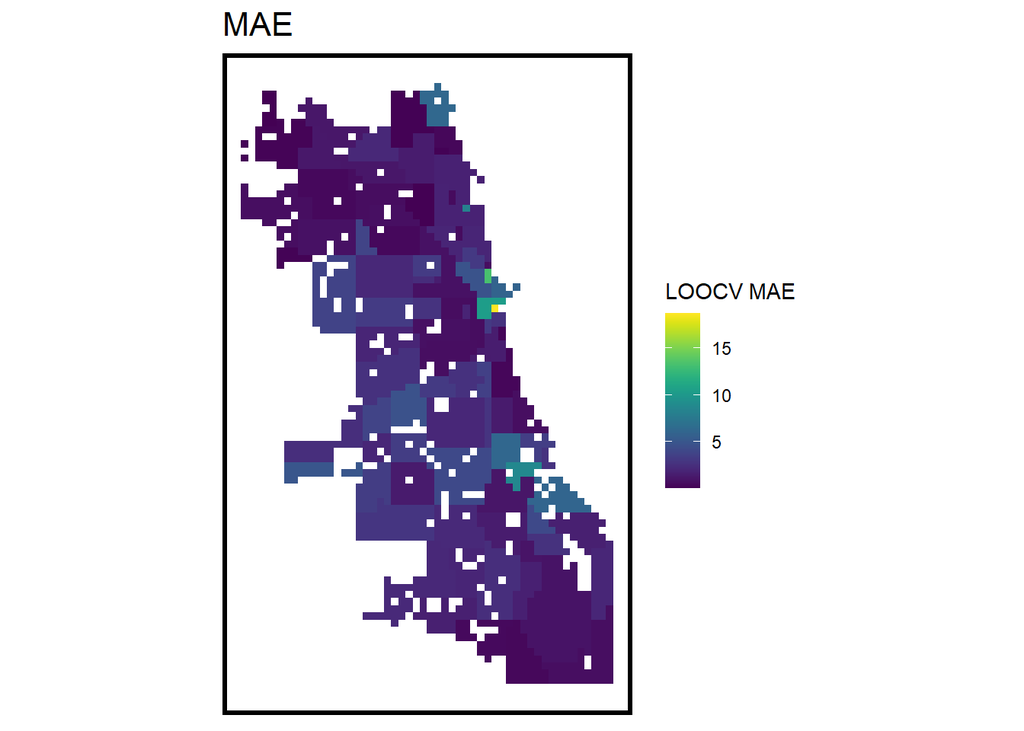

```r
ggplot() +
  geom_sf(data=error_by_reg_and_fold, aes(fill=MAE),color=NA) +
  scale_fill_viridis(name="LOOCV MAE") +
      labs(title="MAE") +
      mapTheme()
```

```r
#Summarizing MAE and SD for each regression.

stargazer(data=as.data.frame(error_by_reg_and_fold),type="text")
```

```
##
## ============================================
## Statistic  N   Mean  St. Dev.   Min    Max
## --------------------------------------------
## Mean_Error 96 -0.530  3.755   -18.703 5.044
## MAE        96 2.562   2.784    0.108  18.703
## SD_MAE     96 2.562   2.784    0.108  18.703
## --------------------------------------------
```

```r
stargazer(data=MAE.cv,type="text")
```

```
##
## ========================================
## Statistic  N  Mean  St. Dev.  Min   Max
## ----------------------------------------
## MAE.cv    100 4.183  0.723   2.180 5.736
## ----------------------------------------
```

## Density vs predictions

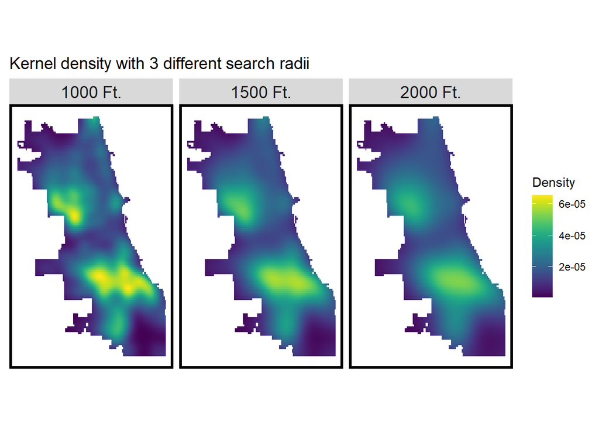

```r
# demo of kernel width
vandal_ppp <- as.ppp(st_coordinates(vandalism), W = st_bbox(final_net))
vandal_KD.1000 <- spatstat.core::density.ppp(vandal_ppp, 1000)
vandal_KD.1500 <- spatstat.core::density.ppp(vandal_ppp, 1500)
vandal_KD.2000 <- spatstat.core::density.ppp(vandal_ppp, 2000)
vandal_KD.df <- rbind(
  mutate(data.frame(rasterToPoints(mask(raster(vandal_KD.1000), as(neighborhoods, 'Spatial')))), Legend = "1000 Ft."),
  mutate(data.frame(rasterToPoints(mask(raster(vandal_KD.1500), as(neighborhoods, 'Spatial')))), Legend = "1500 Ft."),
  mutate(data.frame(rasterToPoints(mask(raster(vandal_KD.2000), as(neighborhoods, 'Spatial')))), Legend = "2000 Ft."))

vandal_KD.df$Legend <- factor(vandal_KD.df$Legend, levels = c("1000 Ft.", "1500 Ft.", "2000 Ft."))

ggplot(data=vandal_KD.df, aes(x=x, y=y)) +
  geom_raster(aes(fill=layer)) +
  facet_wrap(~Legend) +
  coord_sf(crs=st_crs(final_net)) +
  scale_fill_viridis(name="Density") +
  labs(title = "Kernel density with 3 different search radii") +
  mapTheme(title_size = 14)
```

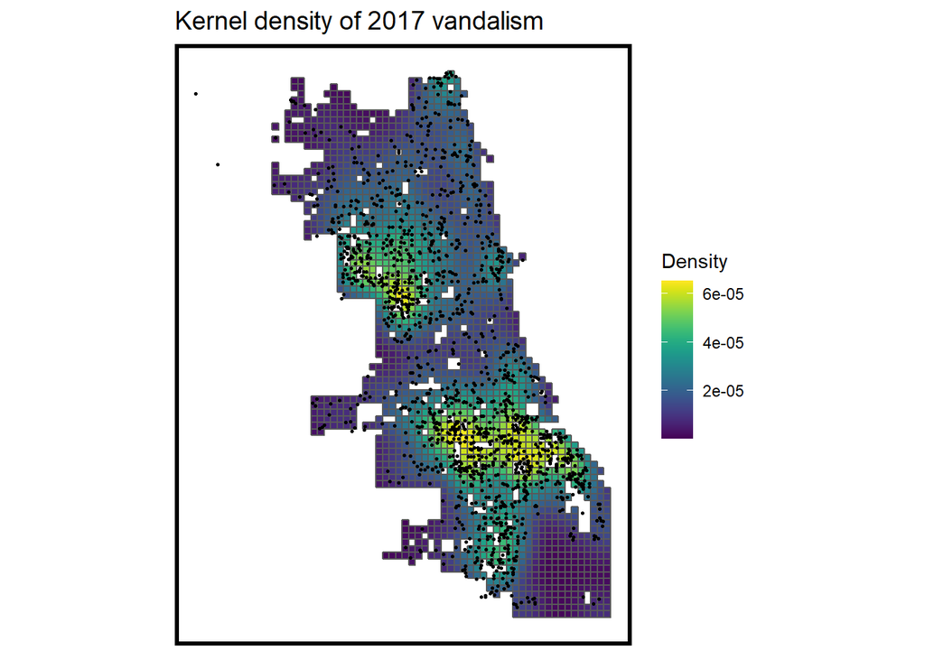

```r
as.data.frame(vandal_KD.1000) %>%
  st_as_sf(coords = c("x", "y"), crs = st_crs(final_net)) %>%
  aggregate(., final_net, mean) %>%
   ggplot() +
     geom_sf(aes(fill=value)) +
     geom_sf(data = sample_n(vandalism, 1500), size = .5) +
     scale_fill_viridis(name = "Density") +
     labs(title = "Kernel density of 2017 vandalism") +
     mapTheme(title_size = 14)
```

## Get 2018 crime data

We are comparing how our model performed relative to the following year’s data.

```r
vandalism18 <-
  read.socrata("https://data.cityofchicago.org/Public-Safety/Crimes-2018/3i3m-jwuy") %>%
  filter(Primary.Type == "CRIMINAL DAMAGE" &
         Description == "TO PROPERTY") %>%
  mutate(x = gsub("[()]", "", Location)) %>%
  separate(x,into= c("Y","X"), sep=",") %>%
  mutate(X = as.numeric(X),
         Y = as.numeric(Y)) %>%
  na.omit %>%
  st_as_sf(coords = c("X", "Y"), crs = 4326, agr = "constant") %>%
  st_transform('ESRI:102271') %>%
  distinct() %>%
  .[fishnet,]
```

```r
vandal_KDE_sum <- as.data.frame(vandal_KD.1000) %>%
  st_as_sf(coords = c("x", "y"), crs = st_crs(final_net)) %>%
  aggregate(., final_net, mean)
kde_breaks <- classIntervals(vandal_KDE_sum$value,
                             n = 5, "fisher")
vandal_KDE_sf <- vandal_KDE_sum %>%
  mutate(label = "Kernel Density",
         Risk_Category = classInt::findCols(kde_breaks),
         Risk_Category = case_when(
           Risk_Category == 5 ~ "5th",
           Risk_Category == 4 ~ "4th",
           Risk_Category == 3 ~ "3rd",
           Risk_Category == 2 ~ "2nd",
           Risk_Category == 1 ~ "1st")) %>%
  cbind(
    aggregate(
      dplyr::select(vandalism18) %>% mutate(vandalCount = 1), ., sum) %>%
    mutate(vandalCount = replace_na(vandalCount, 0))) %>%
  dplyr::select(label, Risk_Category, vandalCount)
```

```r
ml_breaks <- classIntervals(reg.ss.spatialCV$Prediction,
                             n = 5, "fisher")
vandal_risk_sf <-
  reg.ss.spatialCV %>%
  mutate(label = "Risk Predictions",
         Risk_Category =classInt::findCols(ml_breaks),
         Risk_Category = case_when(
           Risk_Category == 5 ~ "5th",
           Risk_Category == 4 ~ "4th",
           Risk_Category == 3 ~ "3rd",
           Risk_Category == 2 ~ "2nd",
           Risk_Category == 1 ~ "1st")) %>%
  cbind(
    aggregate(
      dplyr::select(vandalism18) %>% mutate(vandalCount = 1), ., sum) %>%
      mutate(vandalCount = replace_na(vandalCount, 0))) %>%
  dplyr::select(label,Risk_Category, vandalCount)
```

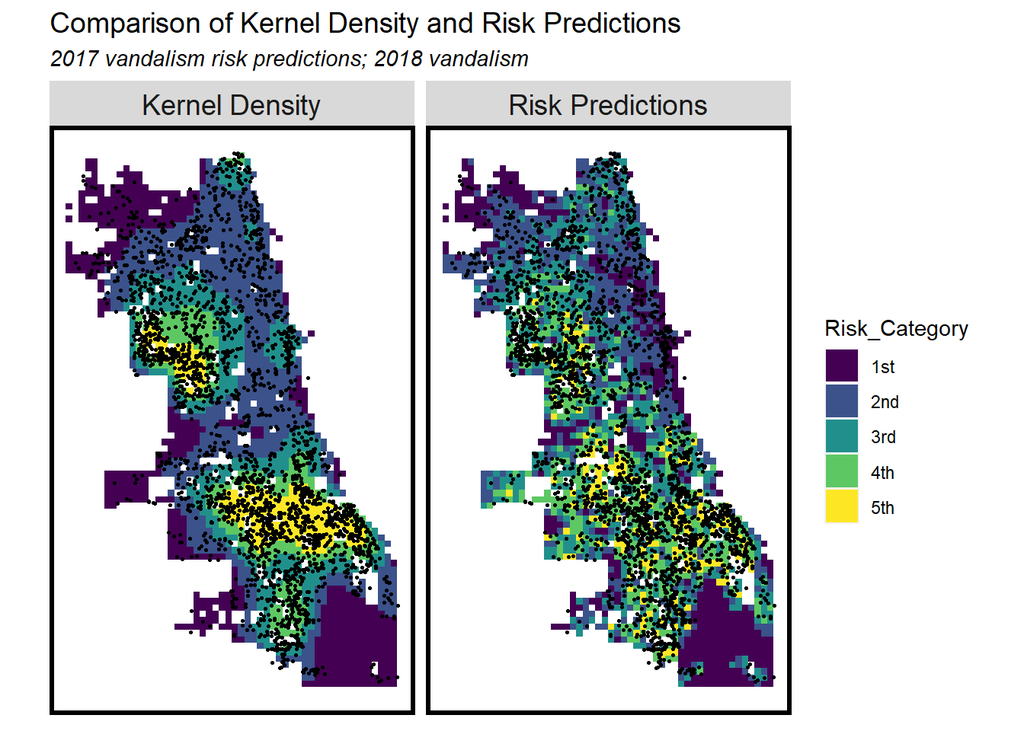

```r
rbind(vandal_KDE_sf, vandal_risk_sf) %>%
  na.omit() %>%
  gather(Variable, Value, -label, -Risk_Category, -geometry) %>%
  ggplot() +
    geom_sf(aes(fill = Risk_Category), colour = NA) +
    geom_sf(data = sample_n(vandalism18, 3000), size = .5, colour = "black") +
    facet_wrap(~label, ) +
    scale_fill_viridis(discrete = TRUE) +
    labs(title="Comparison of Kernel Density and Risk Predictions",
         subtitle="2017 vandalism risk predictions; 2018 vandalism") +
    mapTheme(title_size = 14)
```

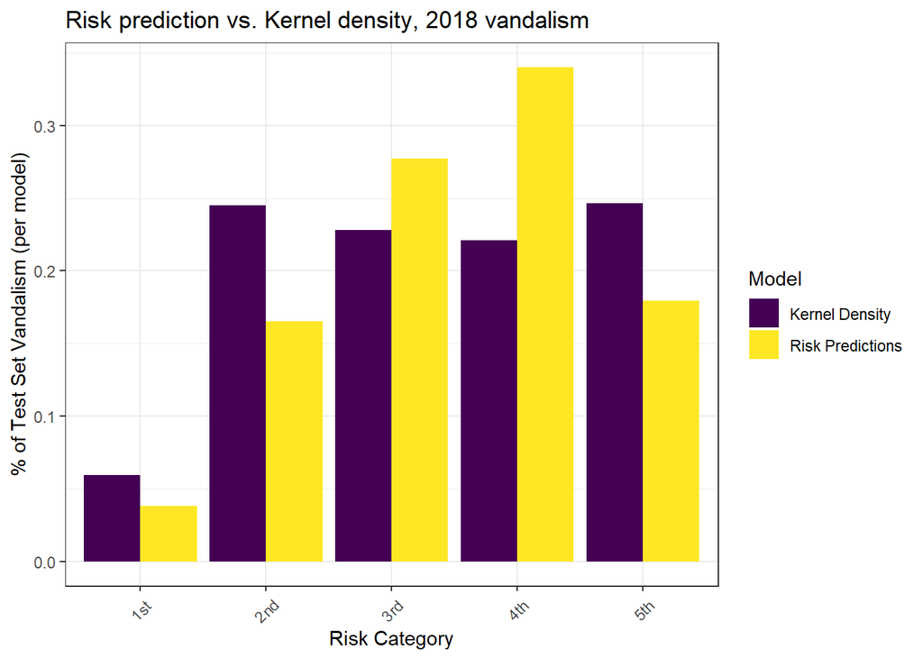

```r
rbind(vandal_KDE_sf, vandal_risk_sf) %>%
  st_drop_geometry() %>%
  na.omit() %>%
  gather(Variable, Value, -label, -Risk_Category) %>%
  group_by(label, Risk_Category) %>%
  summarize(countVandalism = sum(Value)) %>%
  ungroup() %>%
  group_by(label) %>%
  mutate(Pcnt_of_test_set_crimes = countVandalism / sum(countVandalism)) %>%
    ggplot(aes(Risk_Category,Pcnt_of_test_set_crimes)) +
      geom_bar(aes(fill=label), position="dodge", stat="identity") +
      scale_fill_viridis(discrete = TRUE, name = "Model") +
      labs(title = "Risk prediction vs. Kernel density, 2018 vandalism",
           y = "% of Test Set Vandalism (per model)",
           x = "Risk Category") +
  theme_bw() +
      theme(axis.text.x = element_text(angle = 45, vjust = 0.5))
```

## Conclusion

Our mean absolute error is around 2.6 vandalism reports. Considering that the mean number of vandalism reports per area is around 6, our error is not large enough to predict a false negative for an area. That means that law enforcement will be able to narrow down which areas to patrol for vandalism relatively well. While a useful model, in order to improve the predictions, the model could be changed to include more variables or transform our dependent variable to be normally distributed.